# STAT 420: Homework 10

Kwon, YoungJu

2018/07/17

# Directions

Students are encouraged to work together on homework using the discussion boards. However, sharing, copying, or providing any part of a homework solution or code is an infraction of the University’s rules on academic integrity. Any violation will be punished as severely as possible.

- Your assignment must be submitted through Coursera. You are required to upload one `.zip` file, named `hw10_yourNetID.zip`, which contains:
  - Your RMarkdown file which should be saved as `hw10_yourNetID.Rmd`. For example `hw10_dalpiaz2.Rmd`.
  - The result of knitting your RMarkdown file as `hw10_yourNetID.html`. For example `hw10_dalpiaz2.html`.
  - Any outside data provided as a `.csv` file used for the homework.
  - This will roughly match the `.zip` provided.
- Your resulting `.html` file will be considered a “report” which is the material that will determine the majority of your grade. Be sure to visibly include all `R` code and output that is relevant to answering the exercises. (You do not need to include irrelevant code you tried that resulted in error or did not answer the question correctly.)
- You are granted an unlimited number of submissions, but only the last submission *before* the deadline will be viewed and graded.
- If you use this `.Rmd` file as a template, be sure to remove the quotation, directions section, and consider removing `eval = FALSE` from any code chunks provided (if you would like to run that code as part of your assignment).
- Your `.Rmd` file should be written such that, when stored in a folder with any data you are asked to import, it will knit properly without modification. If your `.zip` file is organized properly, this should not be an issue.
- Unless otherwise stated, you may use `R` for each of the exercises.
- Be sure to read each exercise carefully!
- Include your name and NetID in the final document, not only in your filenames.

# Assignment

## Exercise 1 (TV Is Healthy?)

For this exercise we will use the `tvdoctor` data, which can be found in the `faraway` package. After loading the `faraway` package, use `?tvdoctor` to learn about this dataset.

```r
library(faraway)
```

**(a)** Fit a simple linear regression with `life` as the response and `tv` as the predictor. Plot a scatterplot and add the fitting line. Check the assumptions of this model.

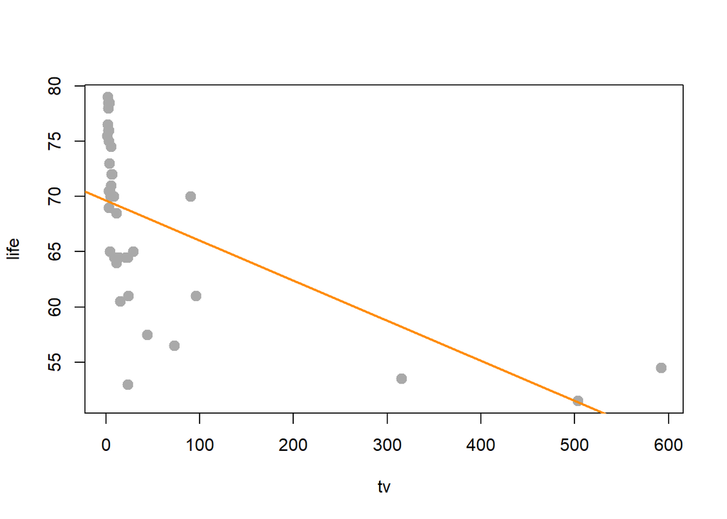

```r
lm_tv = lm(life~tv, data = tvdoctor)
plot(life~tv, data=tvdoctor, pch=20, cex =2, col="darkgrey")
abline(lm_tv, col="darkorange", lwd=2, lty=1)
```

Scatter plot and linear regression line clearly show that predictor `tv` does not properly predict the response.

**(b)** Fit higher order polynomial models of degree 3, 5, and 7. For each, plot a fitted versus residuals plot and comment on the constant variance assumption. Based on those plots, which of these three models do you think are acceptable? Use a statistical test(s) to compare the models you just chose. Based on the test, which is preferred? Check the normality assumption of this model. Identify any influential observations of this model.

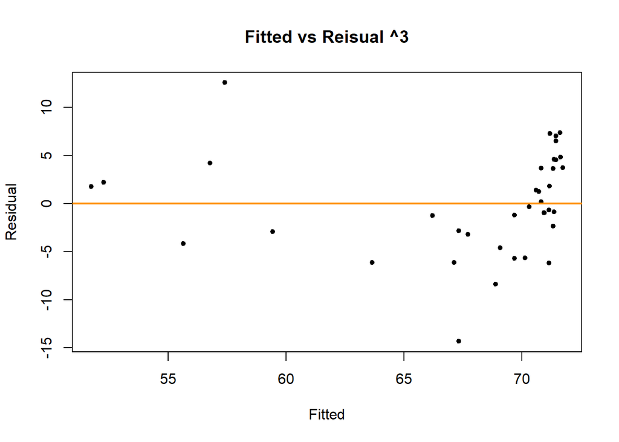

```r
lm_tv3 = lm(life~poly(tv, 3), data =tvdoctor)
lm_tv5 = lm(life~poly(tv, 5), data =tvdoctor)
lm_tv7 = lm(life~poly(tv, 7), data =tvdoctor)

plot(fitted(lm_tv3),resid(lm_tv3), xlab= "Fitted", ylab= "Residual", col="grey0", pch=20, main ="Fitted vs Reisual ^3")
abline(h=0, col="darkorange", lwd=2)
```

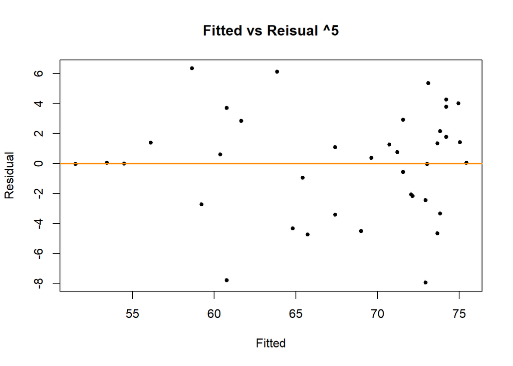

```r
plot(fitted(lm_tv5),resid(lm_tv5), xlab= "Fitted", ylab= "Residual", col="grey0", pch=20, main ="Fitted vs Reisual ^5")
abline(h=0, col="darkorange", lwd=2)
```

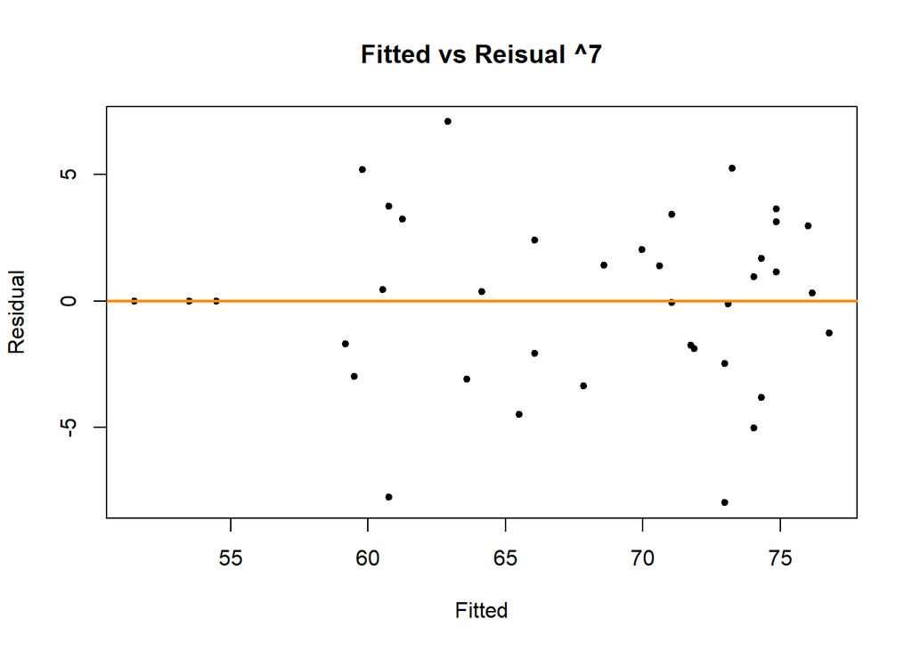

```r
plot(fitted(lm_tv7),resid(lm_tv7), xlab= "Fitted", ylab= "Residual", col="grey0", pch=20, main ="Fitted vs Reisual ^7")
abline(h=0, col="darkorange", lwd=2)
```

```r
library(lmtest)
bptest(lm_tv3)
```

```
##
##  studentized Breusch-Pagan test
##
## data:  lm_tv3
## BP = 3.8, df = 3, p-value = 0.3
```

```r
bptest(lm_tv5)
```

```
##
##  studentized Breusch-Pagan test
##
## data:  lm_tv5
## BP = 4.1, df = 5, p-value = 0.5
```

```r
bptest(lm_tv7)
```

```
##
##  studentized Breusch-Pagan test
##
## data:  lm_tv7
## BP = 5.8, df = 7, p-value = 0.6
```

For three of polynomial models we see large p-values, thus we cannot reject the null of homodscedasticity.

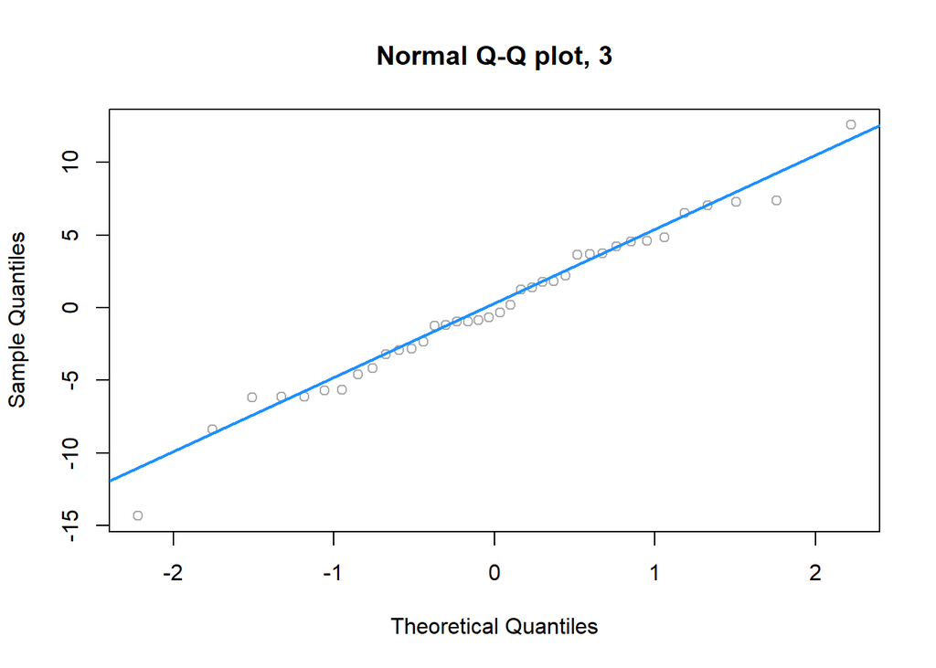

```r
qqnorm(resid(lm_tv3), main = "Normal Q-Q plot, 3", col="darkgrey")
qqline(resid(lm_tv3), col="dodgerblue", lwd=2)
```

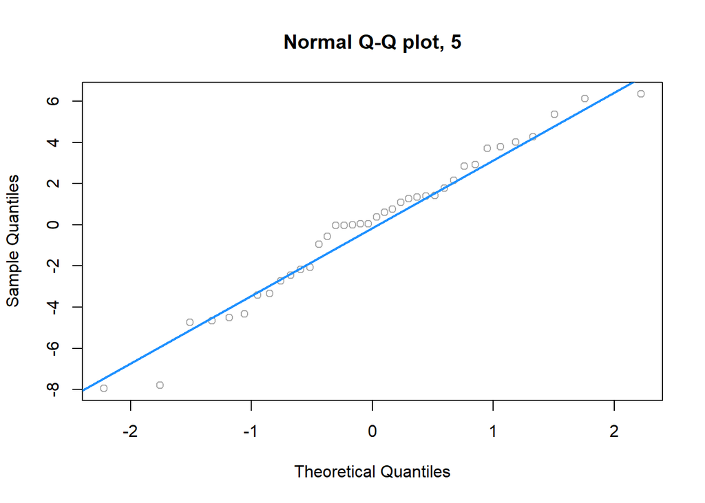

```r
qqnorm(resid(lm_tv5), main = "Normal Q-Q plot, 5", col="darkgrey")
qqline(resid(lm_tv5), col="dodgerblue", lwd=2)
```

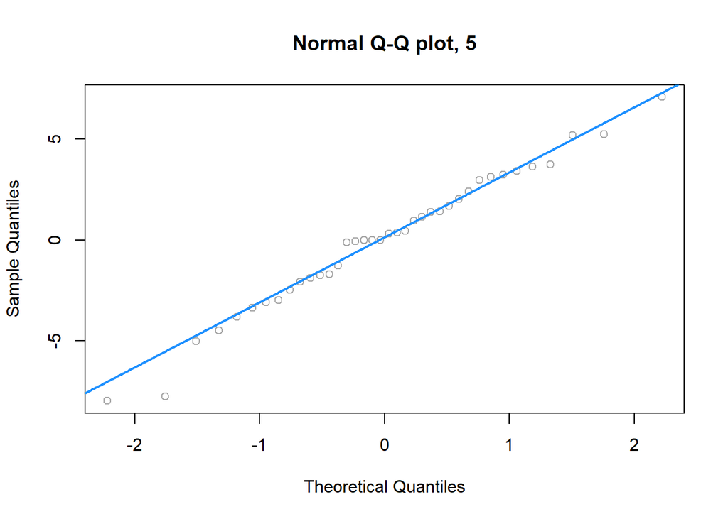

```r
qqnorm(resid(lm_tv7), main = "Normal Q-Q plot, 5", col="darkgrey")
qqline(resid(lm_tv7), col="dodgerblue", lwd=2)
```

```r
shapiro.test(resid(lm_tv3))
```

```
##
##  Shapiro-Wilk normality test
##
## data:  resid(lm_tv3)
## W = 0.98, p-value = 0.9
```

```r
shapiro.test(resid(lm_tv5))
```

```
##
##  Shapiro-Wilk normality test
##
## data:  resid(lm_tv5)
## W = 0.97, p-value = 0.5
```

```r
shapiro.test(resid(lm_tv7))
```

```
##
##  Shapiro-Wilk normality test
##
## data:  resid(lm_tv7)
## W = 0.98, p-value = 0.8
```

With large p-values, all three models fail to reject null hypothesis, normality.

## Exercise 2 (Brains)

The data set `mammals` from the `MASS` package contains the average body weight in kilograms $(x)$ and the average brain weight in grams $(y)$ for $62$ species of land mammals. Use `?mammals` to learn more.

```r
library(MASS)
```

**(a)** What are the smallest and largest body weights in the dataset?

```r
min(mammals$body)
```

```
## [1] 0.005
```

```r
max(mammals$body)
```

```
## [1] 6654
```

**(b)** What are the smallest and largest brain weights in the dataset?

```r
min(mammals$brain)
```

```
## [1] 0.14
```

```r
max(mammals$brain)
```

```
## [1] 5712
```

**(c)** Plot average brain weight $(y)$ versus average body weight $(x)$.

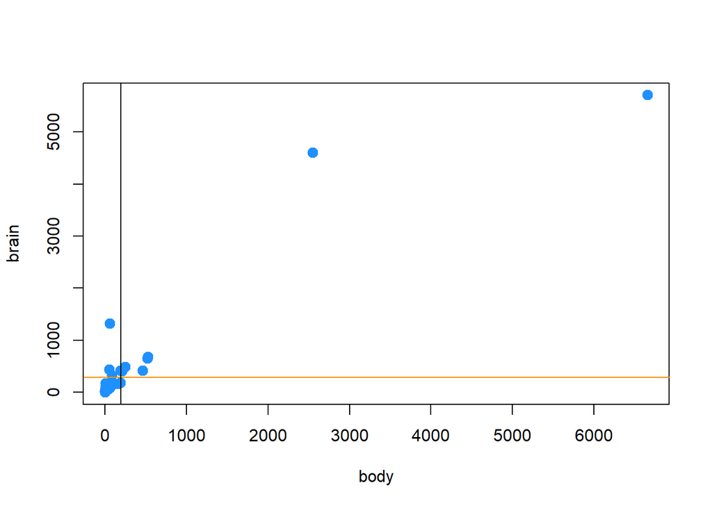

```r
plot(brain~body, data = mammals, col="dodgerblue", pch=20, cex=2)
abline(h=mean(mammals$brain), col="darkorange")
abline(v=mean(mammals$body), col="black")
```

**(d)** Fit a linear model with `brain` as the response and `body` as the predictor. Test for significance of regression. Do you think this is an appropriate model?

```r
lm_ma = lm(brain~body, data=mammals)
summary(lm_ma)
```

```
##
## Call:
## lm(formula = brain ~ body, data = mammals)
##
## Residuals:
##    Min     1Q Median     3Q    Max
## -810.1  -88.5  -79.6  -13.0 2050.3
##
## Coefficients:
##             Estimate Std. Error t value Pr(>|t|)
## (Intercept)  91.0044    43.5526    2.09    0.041 *
## body          0.9665     0.0477   20.28   <2e-16 ***
## ---
## Signif. codes:  0 '***' 0.001 '**' 0.01 '*' 0.05 '.' 0.1 ' ' 1
##
## Residual standard error: 335 on 60 degrees of freedom
## Multiple R-squared:  0.873,  Adjusted R-squared:  0.871
## F-statistic:  411 on 1 and 60 DF,  p-value: <2e-16
```

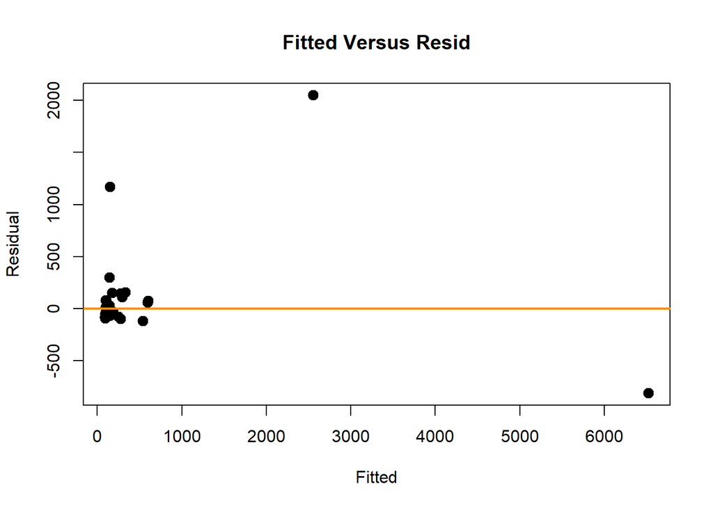

```r
plot(fitted(lm_ma), resid(lm_ma), col="black", main="Fitted Versus Resid", xlab= "Fitted", ylab="Residual", pch=20, cex=2)
abline(h=0, col="darkorange", lwd=2)
```

```r
shapiro.test(resid(lm_ma))
```

```
##
##  Shapiro-Wilk normality test
##
## data:  resid(lm_ma)
## W = 0.41, p-value = 2e-14
```

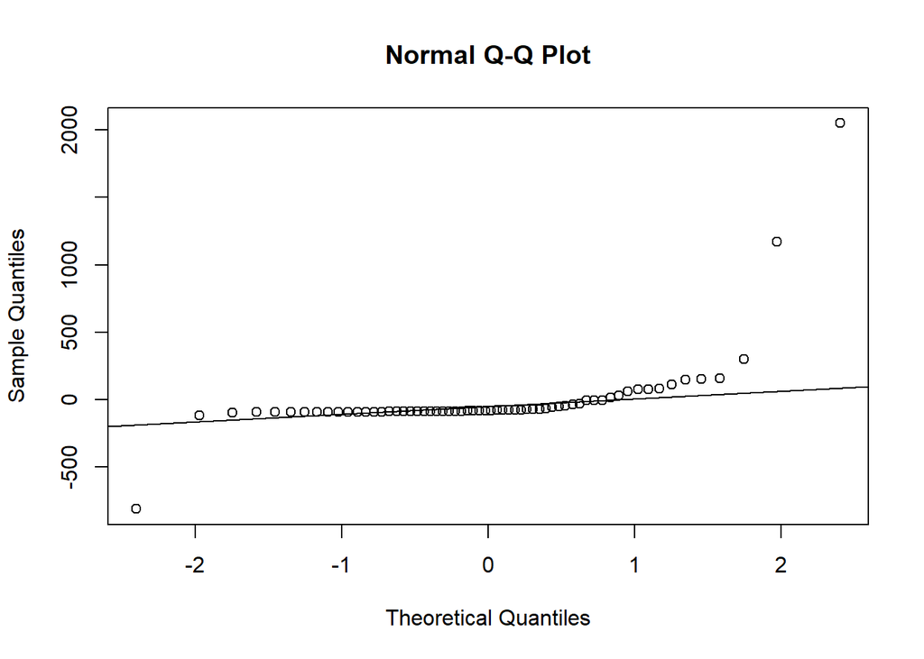

```r
qqnorm(resid(lm_ma))
qqline(resid(lm_ma))
```

Without normality.

Recall, *the log rule*: if the values of a variable range over more than one order of magnitude and the variable is strictly positive, then replacing the variable by its logarithm is likely to be helpful.

**(e)** Since the body weights do range over more than one order of magnitude and are strictly positive, we will use $\log(\text{body weight})$ as our *predictor*, with no further justification. Use the Box-Cox method to verify that $\log(\text{brain weight})$ is then a “recommended” transformation of the *response* variable. That is, verify that $\lambda = 0$ is among the “recommended” values of $\lambda$ when considering,

$$g_\lambda(y) = \beta_0 + \beta_1 \log(\text{body weight})+\epsilon$$

Please include the relevant plot in your results, using an appropriate zoom onto the relevant values.

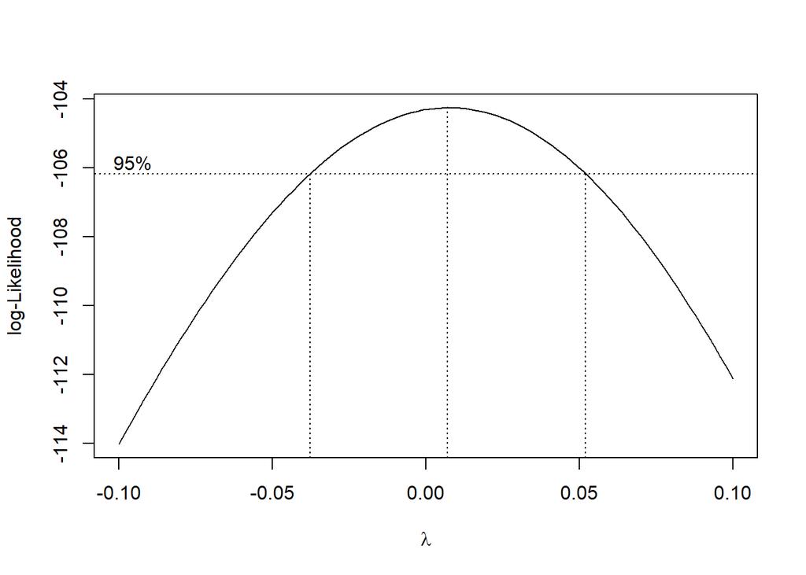

```r
lm_ma_log = lm(brain~log(body), data=mammals)
boxcox(lm_ma_log, plotit = TRUE ,seq(-0.1, 0.1, 0.01))
```

As we can see in the plot, $lambda$ is close to 0. Which justifies $log(y)$

**(f)** Fit the model justified in part **(e)**. That is, fit a model with $\log(\text{brain weight})$ as the response and $\log(\text{body weight})$ as a predictor. Plot $\log(\text{brain weight})$ versus $\log(\text{body weight})$ and add the regression line to the plot. Does a linear relationship seem to be appropriate here?

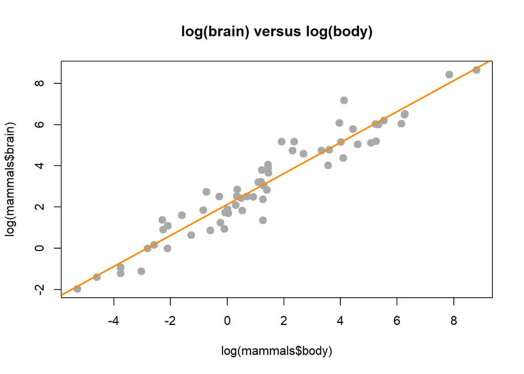

```r
lm_ma_just = lm(log(brain)~log(body) ,data =mammals)
plot(log(mammals$brain)~log(mammals$body), main = "log(brain) versus log(body)", pch=20, col="darkgrey", cex=2)
abline(lm_ma_just, col="darkorange", lwd=2)
```

The line seems to explain the relationship between log(body) and log(brain) very well.

**(g)** Use a Q-Q plot to check the normality of the errors for the model fit in part **(f)**.

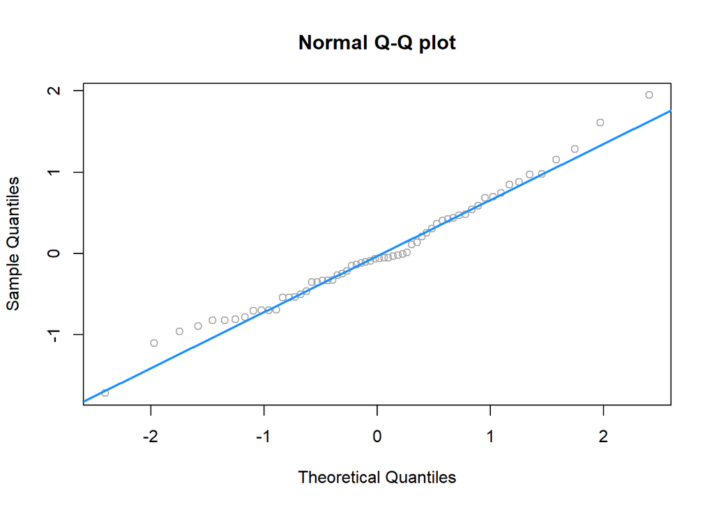

```r
qqnorm(resid(lm_ma_just), main = "Normal Q-Q plot", col="darkgrey")
qqline(resid(lm_ma_just), col="dodgerblue", lwd=2)
```

**(h)** Use the model from part **(f)** to predict the brain weight of a male Pikachu which, has a body weight of 13.4 pounds. (Pikachu would be mammals, right?) Construct a 99% prediction interval.

```r
new_data= data.frame(body=13.4)
log_brain = predict(lm_ma_just, newdata = new_data, interval="prediction", level = 0.99)
exp(log_brain)
```

```
##     fit   lwr   upr
## 1 59.48 9.219 383.7
```

## Exercise 3 (EPA Emissions Data, Redux)

For this exercise we will again use the data stored in `epa2015.csv`. It contains detailed descriptions of 4,411 vehicles manufactured in 2015 that were used for fuel economy testing [as performed by the Environment Protection Agency](https://www3.epa.gov/otaq/tcldata.htm).

**(a)** Recall the model we had finished with last time:

```r
epa2015 = read.csv("epa2015.csv")
co2_int = lm(CO2 ~ horse * type, data = epa2015)
```

Which looked like this:

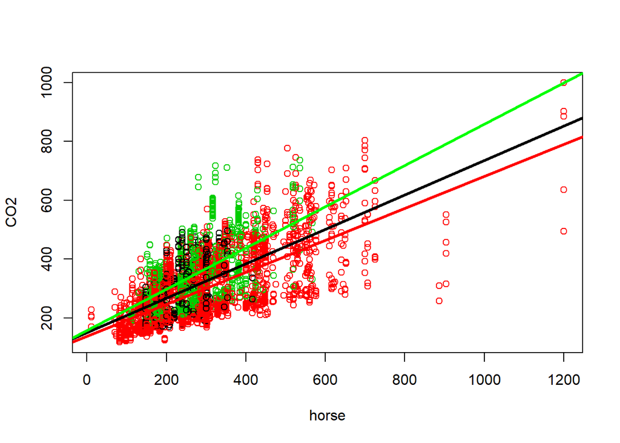

```r
plot(CO2 ~ horse, data = epa2015, col = type)

int_coef = summary(co2_int)$coef[,1]

int_both    = int_coef[1]
int_car     = int_coef[1] + int_coef[3]
int_truck   = int_coef[1] + int_coef[4]

slope_both  = int_coef[2]
slope_car   = int_coef[2] + int_coef[5]
slope_truck = int_coef[2] + int_coef[6]

abline(int_both, slope_both, lwd = 3, col = "black")
abline(int_car, slope_car, lwd = 3, col = "red")
abline(int_truck, slope_truck, lwd = 3, col = "green")
```

Create a fitted vs residuals plot for this model. Do you believe the constant variance assumption has been violated?

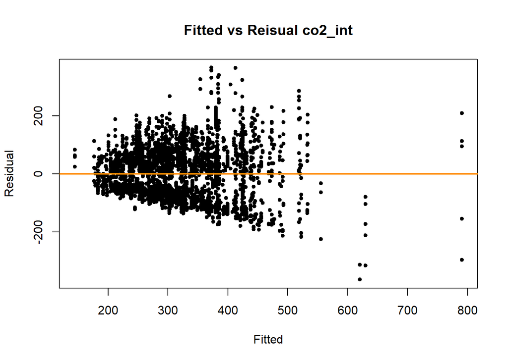

```r
plot(fitted(co2_int),resid(co2_int), xlab= "Fitted", ylab= "Residual", col="grey0", pch=20, main ="Fitted vs Reisual co2_int")
abline(h=0, col="darkorange", lwd=2)
```

It seems like the constant vairance assumption has been violated, the variance grows bigger with larger fitted values.

**(b)** Fit the same model as **(a)** but with a logged response. Create a fitted vs residuals plot for this model. Compare to the previous. Do you believe the constant variance assumption has been violated? Any other assumptions?

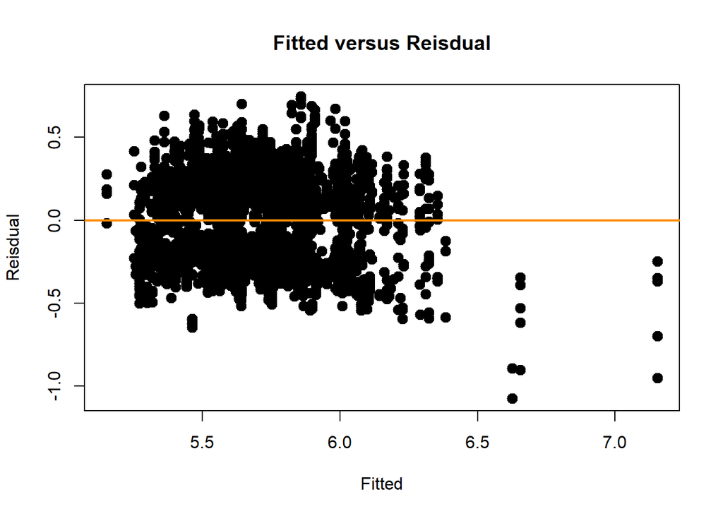

```r
co2_log = lm(log(CO2) ~ horse * type, data = epa2015)
plot(fitted(co2_log), resid(co2_log), xlab="Fitted", ylab="Reisdual", main="Fitted versus Reisdual", col="black", cex=2, pch=20)
abline(h=0, col="darkorange", lwd=2)
```

The variance seems pretty constant excpet few fitted value on high values.

**(c)** Fit a model that has all of the terms from the model in **(b)** as well as a quadratic term for `horse`. Use `log(CO2)` as the response. Create a fitted vs residuals plot for this model. Compare to the previous. Comment on model assumptions.

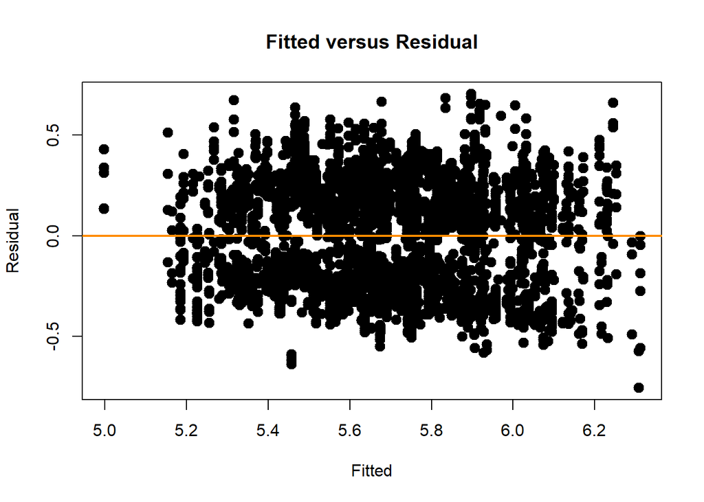

```r
co2_poly =  lm(log(CO2)~ horse*type+I(horse^2), data=epa2015)
plot(fitted(co2_poly), resid(co2_poly), xlab= "Fitted", ylab="Residual", main= "Fitted versus Residual", col="black", cex=2, pch=20)
abline(h=0, col="darkorange", lwd=2)
```

This model looks pretty constant compared to the previous model.

**(d)** Perform further analysis of the model fit in part **(c)**. Can you find any violations of assumptions?

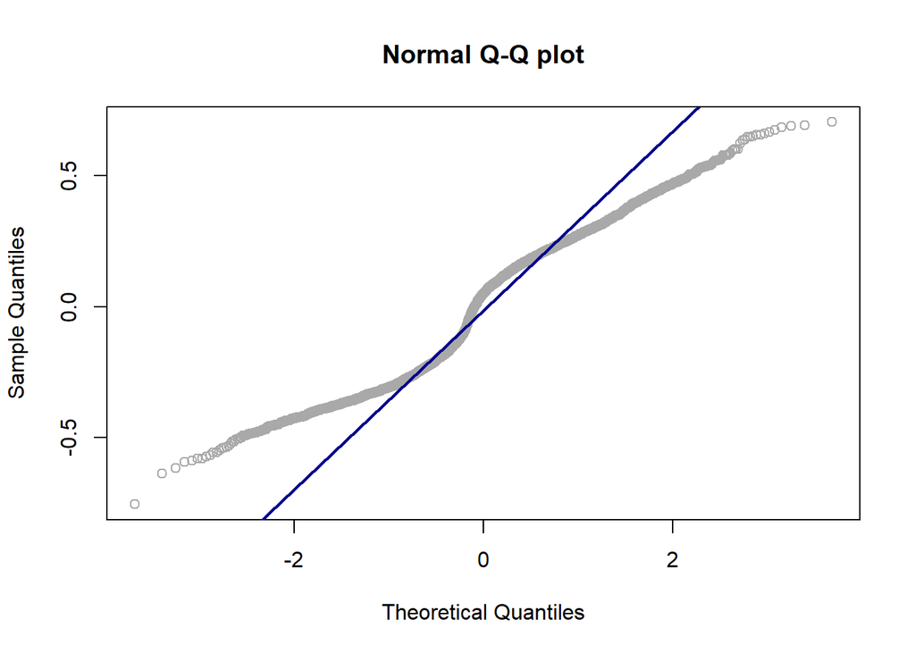

```r
qqnorm(resid(co2_poly), main = "Normal Q-Q plot", col="darkgrey")
qqline(resid(co2_poly), col="darkblue", lwd=2)
```

The polynomial model violates the normality assumption greatly.

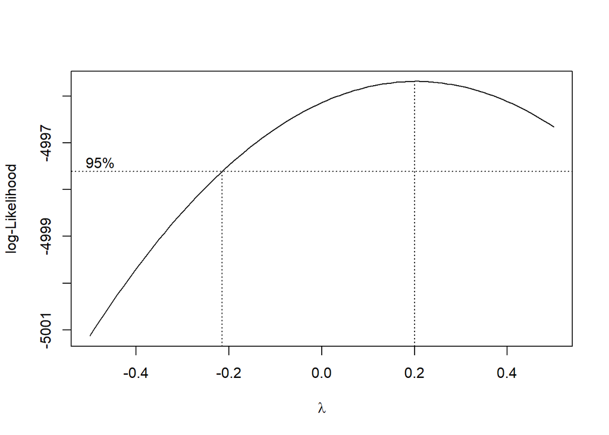

```r
boxcox(co2_poly, plotit = TRUE, seq(-0.5, 0.5, 0.01))
```

```r
shapiro.test(resid(co2_poly))
```

```
##
##  Shapiro-Wilk normality test
##
## data:  resid(co2_poly)
## W = 0.96, p-value <2e-16
```

```r
bptest(co2_poly)
```

```
##
##  studentized Breusch-Pagan test
##
## data:  co2_poly
## BP = 120, df = 6, p-value <2e-16
```

```r
nrow(epa2015[cooks.distance(co2_poly)> 4 / length(cooks.distance(co2_poly)),])
```

```
## [1] 163
```

The model violates normality and constant variance assumption. It also contains 163 influential outliers.

## Exercise 4 (Bigger Is Better?)

Consider the true model,

$$Y = 3 - 4 x + \epsilon,$$

We can simulate observations from this model. We choose a sample size of 40.

```r
n = 40
set.seed(42)
x = runif(n, 0 , 10)
y = 3 - 4 * x + rnorm(n, 0 , 3)
```

Consider two models, one small, one big. The small fits a SLR model. The big fits a polynomial model of degree 10.

```r
fit_slr = lm(y ~ x)
fit_big = lm(y ~ poly(x, 10))
```

The big model has a smaller RMSE.

```r
mean(resid(fit_slr) ^ 2)
```

```
## [1] 9.865
```

```r
mean(resid(fit_big) ^ 2)
```

```
## [1] 7.263
```

However, it is not significant when compared to the small.

```r
anova(fit_slr, fit_big)
```

```
## Analysis of Variance Table
##
## Model 1: y ~ x
## Model 2: y ~ poly(x, 10)
##   Res.Df RSS Df Sum of Sq    F Pr(>F)
## 1     38 395
## 2     29 291  9       104 1.15   0.36
```

By plotting the data and adding the two models, we see the the degree 10 polynomial is *very* wiggly.

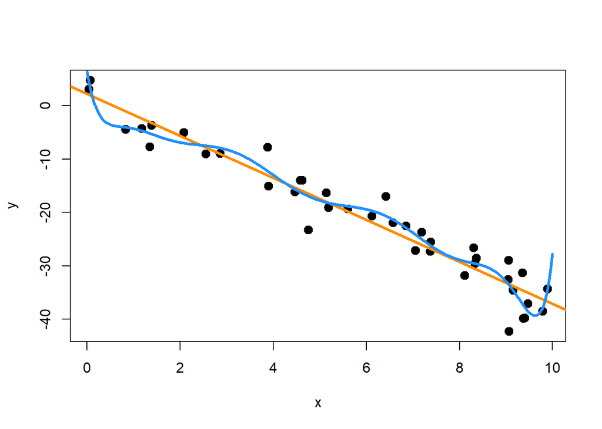

```r
plot(x, y, pch = 20, cex = 2)
abline(fit_slr, col = "darkorange", lwd = 3)
lines(seq(0, 10, 0.01),
      predict(fit_big, newdata = data.frame(x = seq(0, 10, 0.01))),
      col = 'dodgerblue', lwd = 3)
```

**(a)** Use the following code after changing `birthday` to your birthday.

```r
num_sims = 1000
rmse_slr = rep(0, num_sims)
rmse_big = rep(0, num_sims)
pval     = rep(0, num_sims)
birthday = 19920502
set.seed(birthday)
```

Repeat the above process, keeping `x` the same, then re-generating `y` and fitting the SLR and big models `1000` times. Each time, store the RMSE of each model, and the p-value for comparing the two. (In the appropriate variables defined above.)

```r
for(i in 1:num_sims){
  y = 3-4*x+rnorm(n,mean = 0, sd =3)
  fit_slr = lm(y~x)
  fit_big = lm(y~poly(x,10))
  rmse_slr[i] = mean(resid(fit_slr)^2)
  rmse_big[i] = mean(resid(fit_big)^2)
  pval[i] = anova(fit_slr, fit_big)$"Pr(>F)"[2]
}
```

**(b)** What proportion of the RMSEs of the SLR model are smaller than the big model?

```r
mean(rmse_slr<rmse_big)
```

```
## [1] 0
```

**(c)** What proportion of the p-values are less than 0.05?

```r
mean(pval<0.05)
```

```
## [1] 0.041
```

4% of data set.

**(d)** Do you think bigger is better? Based on the pvalue, only 4 percent of big linear model has better explanation. Considering this proportion, the bigger model overfits.